# Exploratorio de datos de casos positivos de covid-19 en el Atlantico

## **Conversion Variable edad**

La variable “Unidad de medida de edad” indica si la edad del paciente está expresada en años, meses o días. En este caso se va a unificar la información y se realizará la conversión de la edad de todos los pacientes a años.

```r
df <- df %>%
  mutate(
    edad = as.numeric(edad),
    unidad_de_medida_de_edad = as.numeric(unidad_de_medida_de_edad),
    edad_años = case_when(
      unidad_de_medida_de_edad == 1 ~ edad,
      unidad_de_medida_de_edad == 2 ~ edad / 12,
      unidad_de_medida_de_edad == 3 ~ edad / 365,
      TRUE ~ edad
    )
  )
```

Resumen Variables

```r
cat("DIMENSIONES:\n")
```

```
## DIMENSIONES:
```

```r
dim(df)
```

```
## [1] 419061     26
```

```r
cat("INFORMACION")
```

```
## INFORMACION
```

```r
glimpse(df)
```

```
## Rows: 419,061
## Columns: 26
## $ fecha_reporte_web            <chr> "16/03/2020 0:00", "16/03/2020 0:00", "24…
## $ id_de_caso                   <chr> "59", "61", "324", "127", "126", "104", "…
## $ fecha_de_notificacion        <chr> "14/03/2020 0:00", "16/03/2020 0:00", "16…
## $ codigo_divipola_departamento <dbl> 8.001, 8.001, 8.001, 8.001, 8.001, 8.001,…
## $ nombre_departamento          <chr> "BARRANQUILLA", "BARRANQUILLA", "BARRANQU…
## $ codigo_divipola_municipio    <dbl> 8.001, 8.001, 8.001, 8.001, 8.001, 8.001,…
## $ nombre_municipio             <chr> "BARRANQUILLA", "BARRANQUILLA", "BARRANQU…
## $ edad                         <dbl> 20, 21, 57, 30, 52, 48, 50, 31, 19, 21, 2…
## $ unidad_de_medida_de_edad     <dbl> 1, 1, 1, 1, 1, 1, 1, 1, 1, 1, 1, 1, 1, 1,…
## $ sexo                         <chr> "M", "M", "M", "F", "F", "F", "F", "M", "…
## $ tipo_de_contagio             <chr> "Importado", "Importado", "Importado", "R…
## $ ubicacion_del_caso           <chr> "Casa", "Casa", "Casa", "Casa", "Casa", "…
## $ estado                       <chr> "Leve", "Leve", "Leve", "Leve", "Leve", "…
## $ codigo_iso_del_pais          <dbl> 724, 724, 591, NA, 840, 724, 840, NA, 724…
## $ nombre_del_pais              <chr> "ESPAÑA", "ESPAÑA", "PANAMA", "Colombia",…
## $ recuperado                   <chr> "Recuperado", "Recuperado", "Recuperado",…
## $ fecha_de_inicio_de_sintomas  <dttm> 2020-03-13, 2020-03-10, 2020-03-16, 2020…
## $ fecha_de_muerte              <dttm> NA, NA, NA, NA, NA, NA, NA, NA, NA, NA, …
## $ fecha_de_diagnostico         <chr> "16/03/2020 0:00", "16/03/2020 0:00", "24…
## $ fecha_de_recuperacion        <dttm> 2020-03-27, 2020-03-24, 2020-03-30, 2020…
## $ tipo_de_recuperacion         <chr> "PCR", "PCR", "PCR", "PCR", "PCR", "PCR",…
## $ pertenencia_etnica           <dbl> 6, 6, 6, 6, 5, 6, 6, 6, 6, 6, 6, 6, 6, 6,…
## $ nombre_del_grupo_etnico      <chr> NA, NA, NA, NA, NA, NA, NA, NA, NA, NA, N…
## $ dias_recuperacion            <dbl> 14, 14, 14, 13, 25, 10, 18, 100, 17, 26, …
## $ dias_hasta_fallecimiento     <dbl> NA, NA, NA, NA, NA, NA, NA, NA, NA, NA, N…
## $ edad_años                    <dbl> 20, 21, 57, 30, 52, 48, 50, 31, 19, 21, 2…
```

```r
head(df)
```

```
## # A tibble: 6 × 26
##   fecha_reporte_web id_de_caso fecha_de_notificacion codigo_divipola_departame…¹
##   <chr>             <chr>      <chr>                                       <dbl>
## 1 16/03/2020 0:00   59         14/03/2020 0:00                              8.00
## 2 16/03/2020 0:00   61         16/03/2020 0:00                              8.00
## 3 24/03/2020 0:00   324        16/03/2020 0:00                              8.00
## 4 19/03/2020 0:00   127        18/03/2020 0:00                              8.00
## 5 19/03/2020 0:00   126        18/03/2020 0:00                              8.00
## 6 19/03/2020 0:00   104        19/03/2020 0:00                              8.00
## # ℹ abbreviated name: ¹codigo_divipola_departamento
## # ℹ 22 more variables: nombre_departamento <chr>,
## #   codigo_divipola_municipio <dbl>, nombre_municipio <chr>, edad <dbl>,
## #   unidad_de_medida_de_edad <dbl>, sexo <chr>, tipo_de_contagio <chr>,
## #   ubicacion_del_caso <chr>, estado <chr>, codigo_iso_del_pais <dbl>,
## #   nombre_del_pais <chr>, recuperado <chr>,
## #   fecha_de_inicio_de_sintomas <dttm>, fecha_de_muerte <dttm>, …
```

## Variables Categoricas

```r
vars_categoricas <- df %>%
  select(where(~ is.character(.) || is.factor(.))) %>%
  names()

vars_categoricas
```

```
##  [1] "fecha_reporte_web"       "id_de_caso"
##  [3] "fecha_de_notificacion"   "nombre_departamento"
##  [5] "nombre_municipio"        "sexo"
##  [7] "tipo_de_contagio"        "ubicacion_del_caso"
##  [9] "estado"                  "nombre_del_pais"
## [11] "recuperado"              "fecha_de_diagnostico"
## [13] "tipo_de_recuperacion"    "nombre_del_grupo_etnico"
```

## Variables Cuantitativas

- Edad
- Dias_de_recuperacion
- dias_hasta_fallecimiento
- Edad_años

# Observaciones Variables importantes

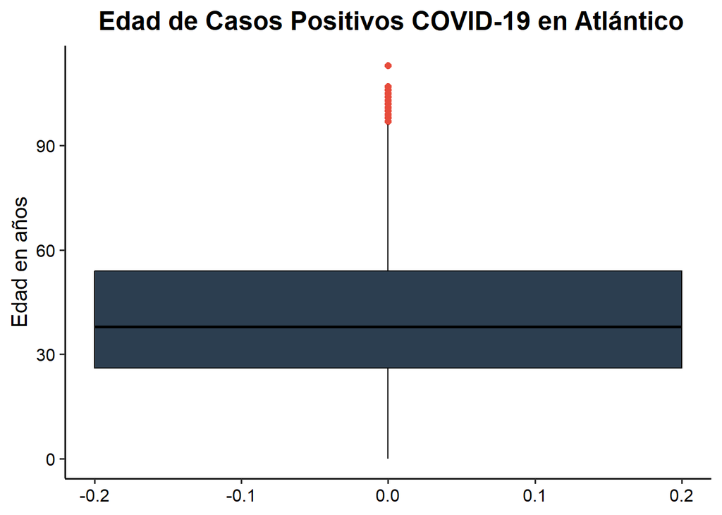

```r
ggplot(df, aes(y = edad_años)) +
  geom_boxplot(
    fill = "#2C3E50",
    color = "black",
    width = 0.4,
    outlier.color = "#E74C3C",
    outlier.size = 2
  ) +
  labs(
    title = " Edad de Casos Positivos COVID-19 en Atlántico",
    y = "Edad en años",
    x = NULL
  ) +
  theme_classic(base_size = 15) +
  theme(
    plot.title = element_text(face = "bold", hjust = 0.5),
    axis.text = element_text(color = "black")
  )
```

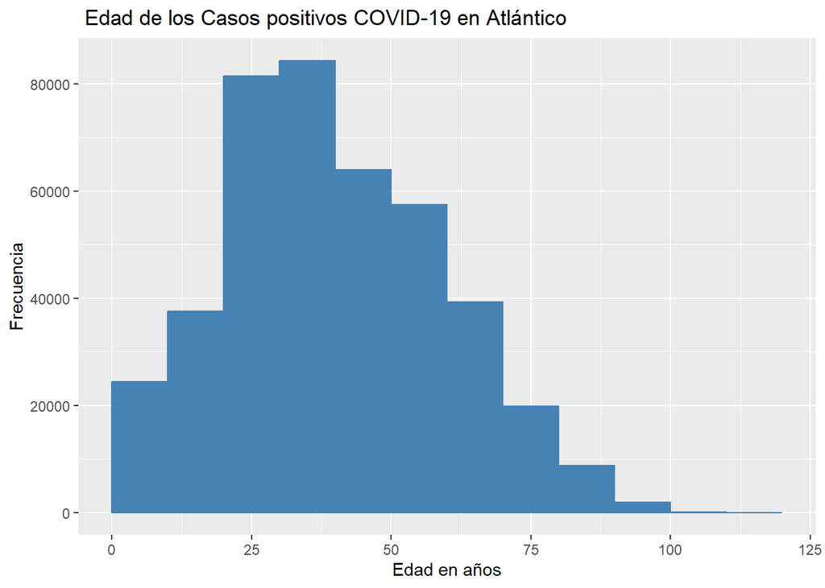

```r
ggplot(df, aes(x = edad_años)) +
  geom_histogram(
    binwidth = 10,
    boundary = 0,
    color = "steelblue",
    fill="steelblue"
  ) +
  labs(
    title = " Edad de los Casos positivos COVID-19 en Atlántico",
    x = "Edad en años",
    y = "Frecuencia"
  )
```

A partir de las gráficas se puede observar que la mayor proporción de casos positivos de COVID-19 corresponde a personas con edades aproximadamente entre los 30 y 40 años.

```r
library(dplyr)
library(lubridate)
library(tidyr)

# Asegurar formato fecha
df <- df %>%
  mutate(
    fecha_de_notificacion = as.Date(fecha_de_notificacion)
  )

tabla_casos <- df %>%
  filter(!is.na(fecha_de_notificacion)) %>%
  mutate(
    año = year(fecha_de_notificacion),
    mes = month(fecha_de_notificacion)
  ) %>%
  count(año, mes) %>%
  complete(
    año = 2020:2024,
    mes = 1:12,
    fill = list(n = 0)
  ) %>%
  pivot_wider(
    names_from = mes,
    values_from = n
  ) %>%
  arrange(año)


colnames(tabla_casos)[-1] <- c(
  "Enero","Febrero","Marzo","Abril","Mayo","Junio",
  "Julio","Agosto","Septiembre","Octubre","Noviembre","Diciembre"
)

tabla_casos
```

```
## # A tibble: 36 × 13
##      año Enero Febrero Marzo Abril  Mayo Junio Julio Agosto Septiembre Octubre
##    <dbl> <int>   <int> <int> <int> <int> <int> <int>  <int>      <int>   <int>
##  1     1  1468     737   472  1731  1031  1353  2024    554        234     377
##  2     2  1866     609   630  1552   863  1147  1829    596        255     473
##  3     3  2145     530   673  2170  1411  1348  1694    855        439     344
##  4     4  3307     474   609  1493  2068  1223  1815    648        334     423
##  5     5  3186     401   527  2571  1192  1447  1468    595        237     472
##  6     6  2886     355   469  2989  1888  1165  1942    859        308     328
##  7     7  3401     325   826  3994  1532  1115  1658    367        335     362
##  8     8  3344     456   867  3178  1209  2005  1931    439        320     421
##  9     9  2768     472   950  3337   870  1520  1519    403        335     403
## 10    10  2390     397  1010  2936  1748  1792  1453    521        337     351
## # ℹ 26 more rows
## # ℹ 2 more variables: Noviembre <int>, Diciembre <int>
```

Casos por Municipio:

```r
top_mun <- df %>%
  count(nombre_municipio) %>%
  arrange(desc(n)) %>%
  slice(1:12)

library(scales)
```

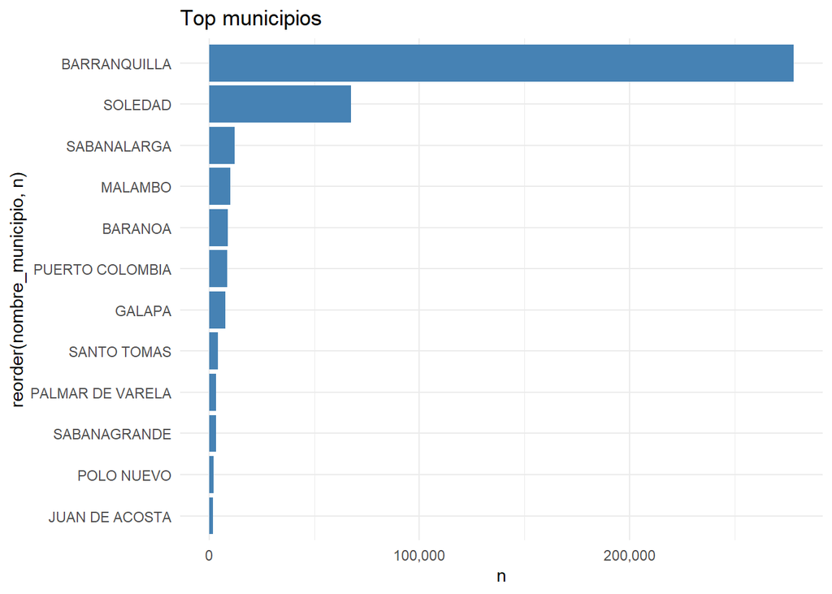

```r
ggplot(top_mun, aes(x = reorder(nombre_municipio, n), y = n)) +
  geom_col(fill = "steelblue") +
  coord_flip() +
  scale_y_continuous(labels = comma) +
  theme_minimal() +
  labs(title = "Top municipios")
```

A partir del grafico de Barras, se puede observar que la gran mayoria de los casos positvos de covid 19 se concentraron en Barranquilla ,seguido por Soledad y Sabanalarga.

## Tasa de Mortalidad por municipio

```r
tabla <- df %>%
  filter(
    !is.na(nombre_municipio),
    !is.na(recuperado),
    recuperado %in% c("Recuperado", "Fallecido")
  ) %>%
  count(nombre_municipio, recuperado) %>%
  group_by(nombre_municipio) %>%
  mutate(porcentaje = n / sum(n) * 100) %>%
  ungroup()

tabla <- df %>%
  filter(
    !is.na(nombre_municipio),
    nombre_municipio != "NA",
    nombre_municipio != "",
    !is.na(recuperado),
    recuperado %in% c("Recuperado", "Fallecido")
  ) %>%
  count(nombre_municipio, recuperado) %>%
  group_by(nombre_municipio) %>%
  mutate(porcentaje = n / sum(n) * 100) %>%
  ungroup()
df %>% count(nombre_municipio, sort = TRUE) %>% head(10)
```

```
## # A tibble: 10 × 2
##    nombre_municipio      n
##    <chr>             <int>
##  1 BARRANQUILLA     277989
##  2 SOLEDAD           67469
##  3 SABANALARGA       12217
##  4 MALAMBO           10199
##  5 BARANOA            8842
##  6 PUERTO COLOMBIA    8609
##  7 GALAPA             7744
##  8 SANTO TOMAS        4247
##  9 PALMAR DE VARELA   3351
## 10 SABANAGRANDE       3214
```

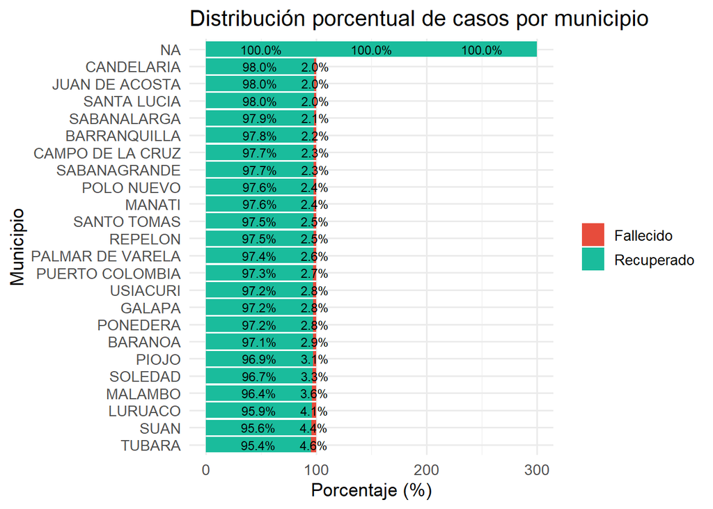

```r
tabla <- df %>%
  filter(
    !is.na(nombre_municipio),
    nombre_municipio != "",
    !is.na(recuperado),
    recuperado %in% c("Recuperado", "Fallecido")
  ) %>%
  count(nombre_municipio, recuperado) %>%
  group_by(nombre_municipio) %>%
  mutate(porcentaje = n / sum(n) * 100) %>%
  ungroup()


orden_municipios <- tabla %>%
  filter(recuperado == "Fallecido") %>%
  arrange(desc(porcentaje)) %>%
  pull(nombre_municipio)

tabla <- tabla %>%
  mutate(nombre_municipio = factor(nombre_municipio,
                                   levels = orden_municipios))


ggplot(tabla, aes(x = porcentaje,
                  y = nombre_municipio,
                  fill = recuperado)) +
  geom_col() +
  geom_text(
    aes(label = sprintf("%.1f%%", porcentaje)),
    position = position_stack(vjust = 0.5),
    size = 3
  ) +
  scale_fill_manual(values = c(
    "Recuperado" = "#1ABC9C",
    "Fallecido" = "#E74C3C"
  )) +
  labs(
    title = "Distribución porcentual de casos por municipio",
    x = "Porcentaje (%)",
    y = "Municipio",
    fill = NULL
  ) +
  theme_minimal(base_size = 13)
```

## Tipo de Contagio:

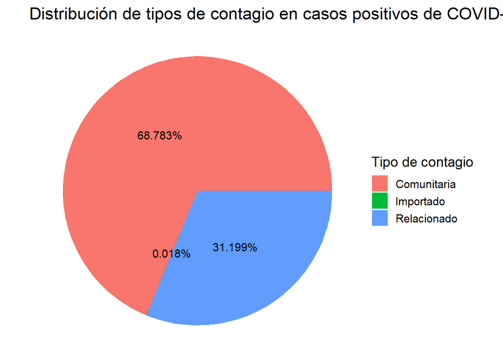

```r
library(dplyr)
library(ggplot2)
library(scales)


contagio_tabla <- df %>%
  count(tipo_de_contagio) %>%
  mutate(
    porcentaje = n / sum(n)
  )


ggplot(contagio_tabla, aes(x = "", y = porcentaje, fill = tipo_de_contagio)) +
  geom_col(width = 1) +
  coord_polar(theta = "y", start = pi/2) +
  geom_text(
    aes(label = percent(porcentaje, accuracy = 0.001)),
    position = position_stack(vjust = 0.5),
    size = 4
  ) +
  labs(
    title = "Distribución de tipos de contagio en casos positivos de COVID-19 en Atlántico",
    fill = "Tipo de contagio"
  ) +
  theme_void(base_size = 14)
```

Con base en los resultados, el tipo de contagio mas comun es el comunitario con un 68%, es decir, cuando no se sabe la fuente exacta del contagio. La segunda forma de contagio mas frecuente es la “relacionada” con un 31%, en donde se sabe que hubo contacto directo con otra persona ya con el virus. Por ultimo, la menos comun es la “importada”, y trata de los casos en donde se contagio en el extranjero y la vino despues al pais.

## Sexo

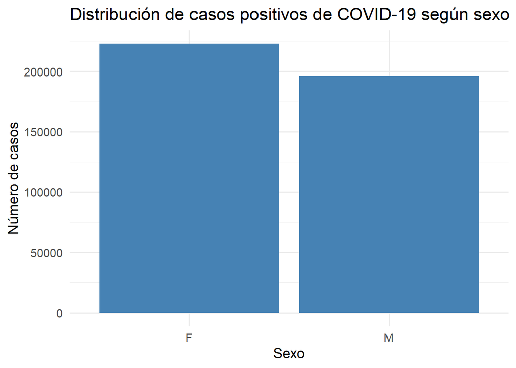

```r
sexo_tabla <- df %>%
  count(sexo)


ggplot(sexo_tabla, aes(x = sexo, y = n)) +
  geom_col(fill = "steelblue") +
  labs(
    title = "Distribución de casos positivos de COVID-19 según sexo",
    x = "Sexo",
    y = "Número de casos"
  ) +
  theme_minimal(base_size = 14)
```

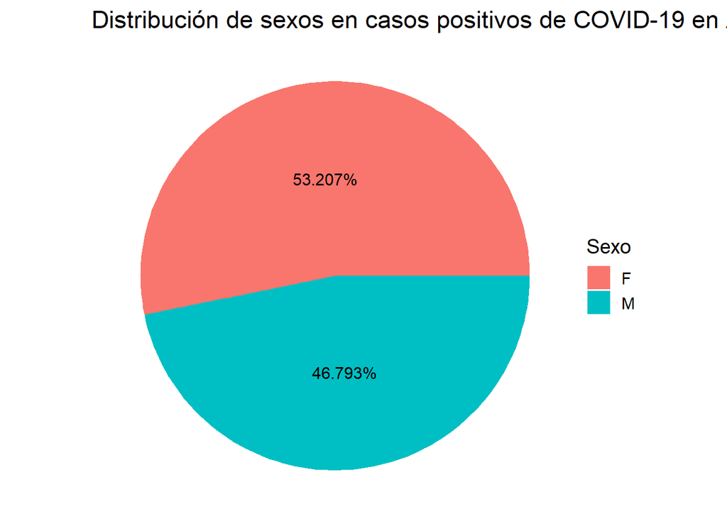

```r
sexo_tabla <- df %>%
  filter(!is.na(sexo)) %>%
  count(sexo) %>%
  mutate(porcentaje = n / sum(n))

ggplot(sexo_tabla, aes(x = "", y = porcentaje, fill = sexo)) +
  geom_col(width = 1) +
  coord_polar(theta = "y", start = pi/2) +
  geom_text(
    aes(label = percent(porcentaje, accuracy = 0.001)),
    position = position_stack(vjust = 0.5),
    size = 4
  ) +
  labs(
    title = "Distribución de sexos en casos positivos de COVID-19 en Atlántico",
    fill = "Sexo"
  ) +
  theme_void(base_size = 14)
```

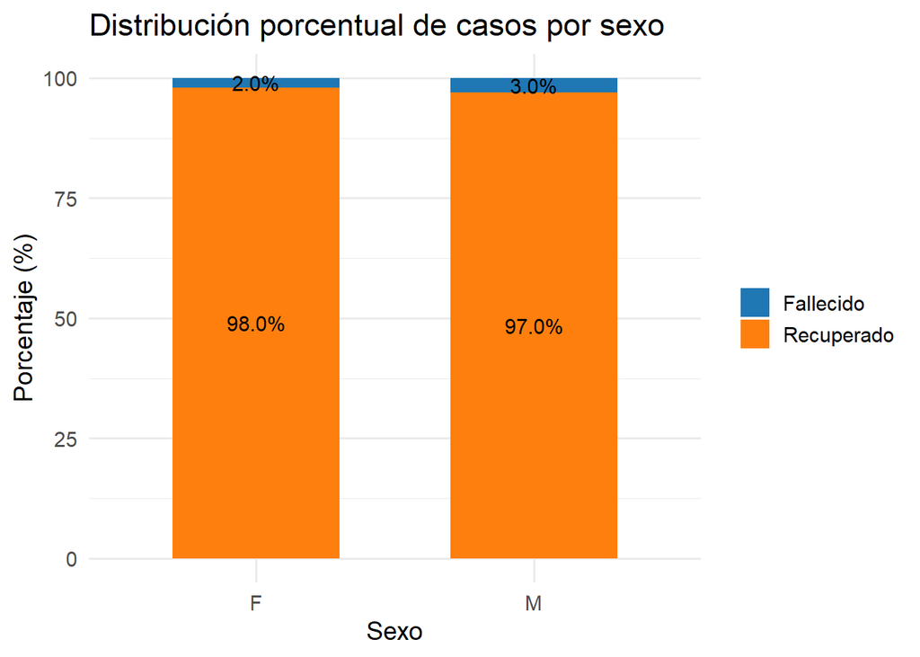

```r
tabla_sexo <- df %>%
  filter(!is.na(sexo),
         !is.na(recuperado),
         recuperado %in% c("Recuperado", "Fallecido")) %>%
  count(sexo, recuperado) %>%
  group_by(sexo) %>%
  mutate(porcentaje = n / sum(n) * 100) %>%
  ungroup()


ggplot(tabla_sexo, aes(x = sexo,
                       y = porcentaje,
                       fill = recuperado)) +
  geom_col(width = 0.6) +
  geom_text(aes(label = sprintf("%.1f%%", porcentaje)),
            position = position_stack(vjust = 0.5),
            size = 4) +
  scale_fill_manual(values = c(
    "Fallecido" = "#1f77b4",
    "Recuperado" = "#ff7f0e"
  )) +
  labs(
    title = "Distribución porcentual de casos por sexo",
    x = "Sexo",
    y = "Porcentaje (%)",
    fill = NULL
  ) +
  theme_minimal(base_size = 14)
```

## Recuperacion:

```r
df %>%
  count(estado, sort = TRUE)
```

```
## # A tibble: 7 × 2
##   estado         n
##   <chr>      <int>
## 1 Leve      400808
## 2 Fallecido  10257
## 3 leve        5075
## 4 N/A         2882
## 5 Moderado      35
## 6 Grave          3
## 7 LEVE           1
```

```r
df <- df %>%
  mutate(
    estado = str_squish(estado),
    estado = str_to_title(estado)
  )
```

```r
df <- df %>%
  mutate(
    recuperado = replace_na(recuperado, "Fallecido")
  )
```

```r
caso_recuperado <- df %>%
  count(recuperado) %>%
  filter(recuperado %in% c("Recuperado", "Fallecido"))
```

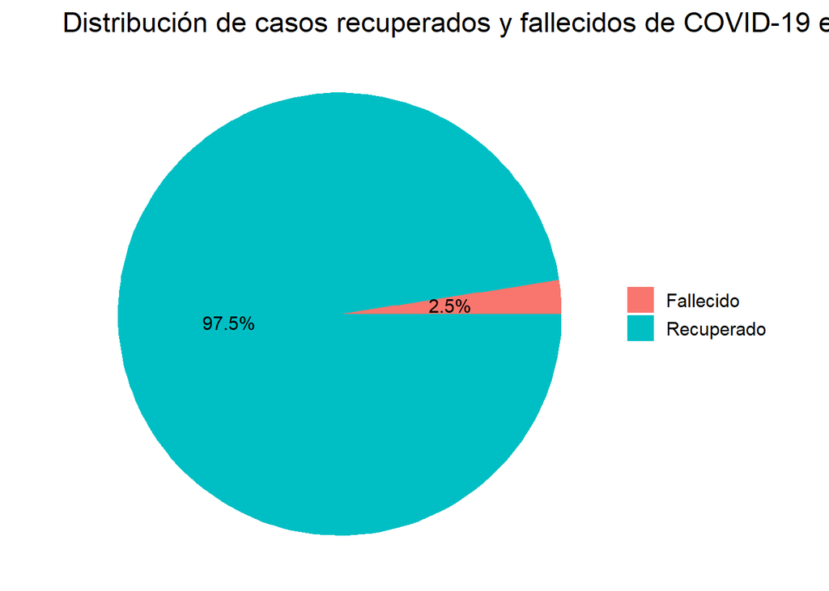

```r
library(ggplot2)
library(scales)

ggplot(caso_recuperado, aes(x = "", y = n, fill = recuperado)) +
  geom_col(width = 1) +
  coord_polar(theta = "y", start = pi/2) +
  geom_text(
    aes(label = percent(n / sum(n), accuracy = 0.1)),
    position = position_stack(vjust = 0.5),
    size = 4
  ) +
  labs(
    title = "Distribución de casos recuperados y fallecidos de COVID-19 en Atlántico",
    fill = NULL
  ) +
  theme_void(base_size = 14)
```

Segun el grafico circular, se puede observar que existe una tasa de mortalidad del 2.5% en los casos positivos del Covid 19 en el Atlantico. Mientras que el restante 97.5% corresponde a los recuperados.

## Dias de recuperacion

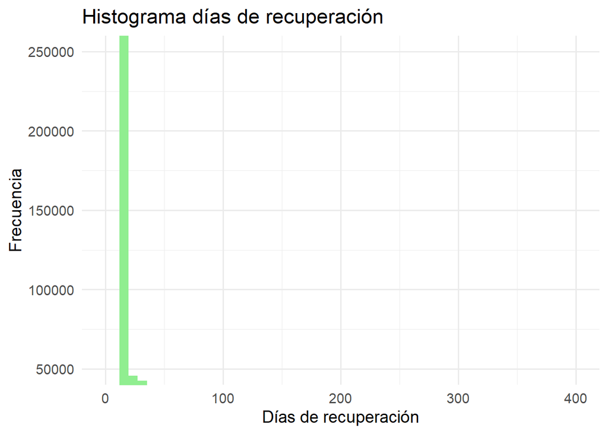

```r
library(ggplot2)

ggplot(df, aes(x = dias_recuperacion)) +
  geom_histogram(bins = 50,fill='lightgreen') +
  coord_cartesian(xlim = c(0, 400), ylim = c(50000, 250000)) +
  scale_y_continuous(breaks = seq(50000, 250000, by = 50000)) +
  labs(
    title = "Histograma días de recuperación",
    x = "Días de recuperación",
    y = "Frecuencia"
  ) +
  theme_minimal(base_size = 14)
```

```r
stats <- df$dias_recuperacion

tabla_dias_de_recuperacion <- data.frame(
  Estadistico = c(
    "Número de casos",
    "Media",
    "Desviación estándar",
    "Mínimo",
    "Percentil 25 (Q1)",
    "Mediana (Q2)",
    "Percentil 75 (Q3)",
    "Máximo"
  ),
  Valor = c(
    sum(!is.na(stats)),
    round(mean(stats, na.rm = TRUE), 2),
    round(sd(stats, na.rm = TRUE), 2),
    round(min(stats, na.rm = TRUE), 0),
    round(quantile(stats, 0.25, na.rm = TRUE), 0),
    round(median(stats, na.rm = TRUE), 0),
    round(quantile(stats, 0.75, na.rm = TRUE), 0),
    round(max(stats, na.rm = TRUE), 0)
  )
)

tabla_dias_de_recuperacion
```

```
##           Estadistico     Valor
## 1     Número de casos 403408.00
## 2               Media     23.23
## 3 Desviación estándar     28.58
## 4              Mínimo      2.00
## 5   Percentil 25 (Q1)     14.00
## 6        Mediana (Q2)     15.00
## 7   Percentil 75 (Q3)     21.00
## 8              Máximo    386.00
```

En este Grafico del histograma se puede analizar que existe una distribucion asimetrica con un gran sesgo hacia la derecha. En la tabla se puede observar que el 50% de los datos de las personas para recuperarse del covid 19 ronda entre los 14 y 21 dias. la media de dias de recuperacion es de 23 dias por lo que esta fuera de este rango intercuartilico debido a la gran dispersion de datos por la cola larga en la derecha, ya que existen pacientes con recuperacion de hasta 386 dias. En este caso la mejor medida tendencia central es la mediana con un valor de 15 dias al presentar mejor comportamiento tipico que la media

## Dias hasta Fallecimiento de pacientes con covid 19

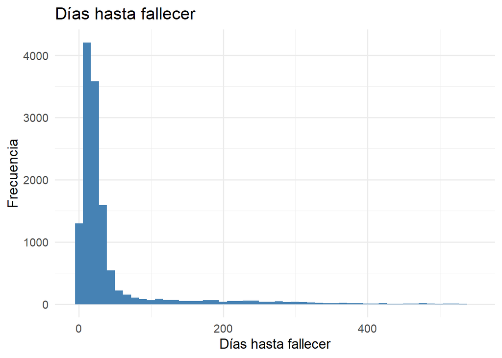

```r
ggplot(df, aes(x = dias_hasta_fallecimiento)) +
  geom_histogram(bins = 50, fill = "steelblue") +
  labs(
    title = "Días hasta fallecer",
    x = "Días hasta fallecer",
    y = "Frecuencia"
  ) +
  theme_minimal(base_size = 14)
```

```r
stats <- df$dias_hasta_fallecimiento

tabla_dias_hasta_fallecer <- data.frame(
  Estadistico = c(
    "Número de casos",
    "Media",
    "Desviación estándar",
    "Mínimo",
    "Percentil 25 (Q1)",
    "Mediana (Q2)",
    "Percentil 75 (Q3)",
    "Máximo"
  ),
  Valor = c(
    sum(!is.na(stats)),
    round(mean(stats, na.rm = TRUE), 2),
    round(sd(stats, na.rm = TRUE), 2),
    round(min(stats, na.rm = TRUE), 0),
    round(quantile(stats, 0.25, na.rm = TRUE), 0),
    round(median(stats, na.rm = TRUE), 0),
    round(quantile(stats, 0.75, na.rm = TRUE), 0),
    round(max(stats, na.rm = TRUE), 0)
  )
)

tabla_dias_hasta_fallecer
```

```
##           Estadistico    Valor
## 1     Número de casos 13130.00
## 2               Media    42.41
## 3 Desviación estándar    74.91
## 4              Mínimo     0.00
## 5   Percentil 25 (Q1)    11.00
## 6        Mediana (Q2)    19.00
## 7   Percentil 75 (Q3)    31.00
## 8              Máximo   543.00
```

si como el anterior analisis, la distribución de días hasta fallecer presenta una fuerte asimetría positiva , con la mayoría de los casos concentrados entre 11 y 31 días .La media es mucho mayor que la mediana debido a valores atipicos en la cola de la derecha que alcanzan hasta 543 días. Entonces, se toma la mediana como la mejor medida central debido a que presenta un mejor comportamiento tipico teniendo un valor de 19 dias.